# trial0

Lukáš Hejtmánek

Thu Jul 09 00:30:14 2020

## Summative heatmaps

### ActiveAvoidance

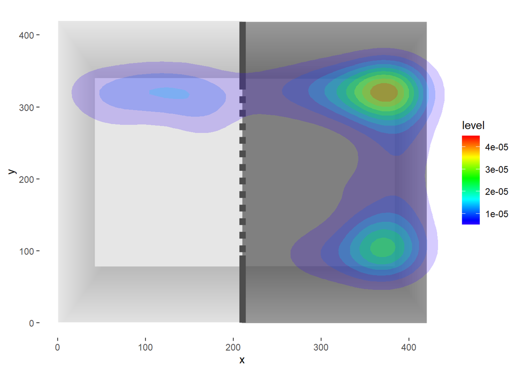

### LightDart Test

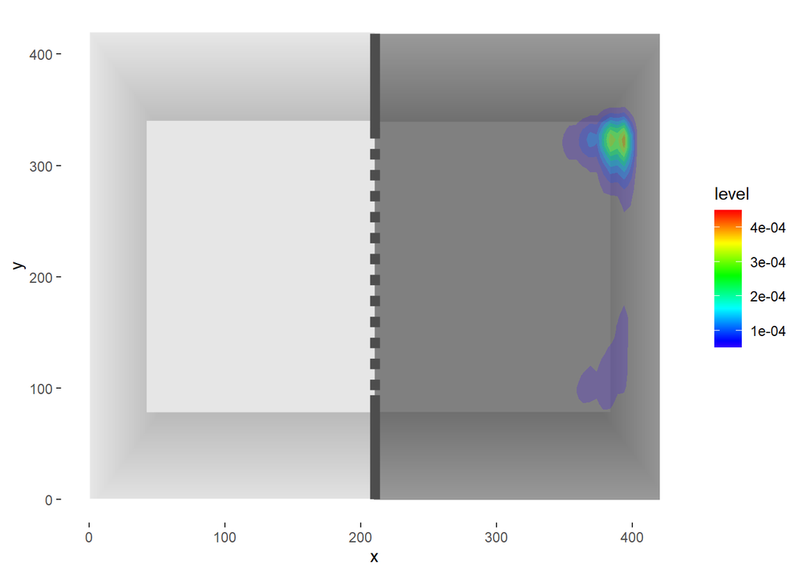

### ActiveAvoidance

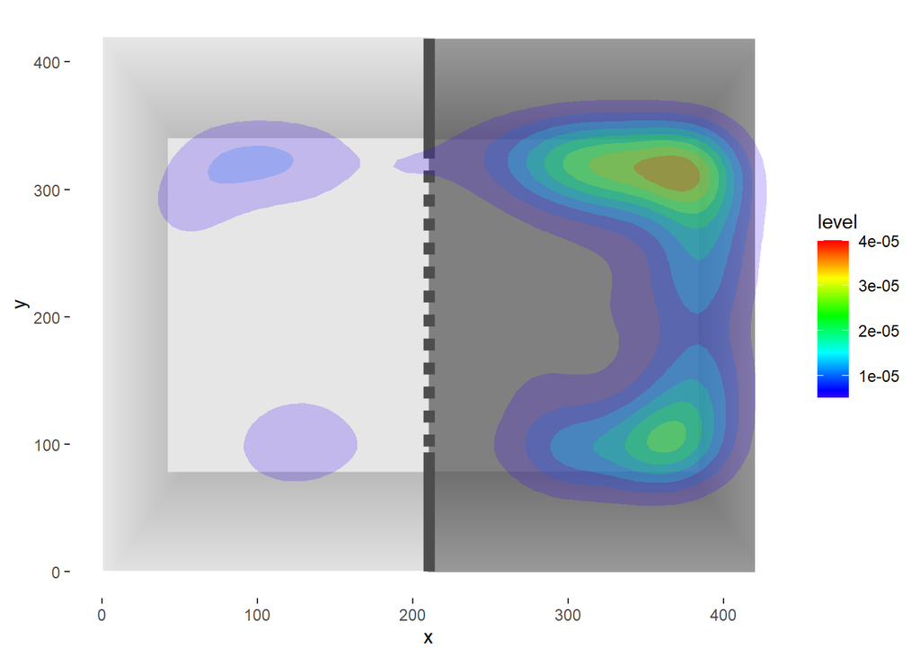

### LightDark Test

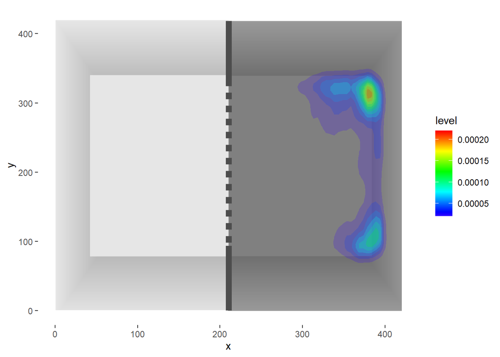

### Individual animals

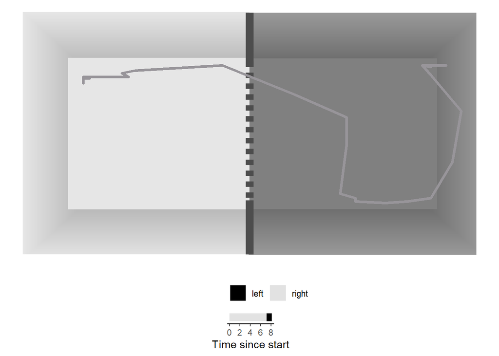

Animal:

animal_1

Distance:

838.92

Time in left zone:

1.01

Time in right zone:

7.17

Time in central zone:

NA

Crosses to the right:

0

Crosses to the left:

1

Number of freezes:

0

Total freeze time:

0

Freeze time ratio:

0

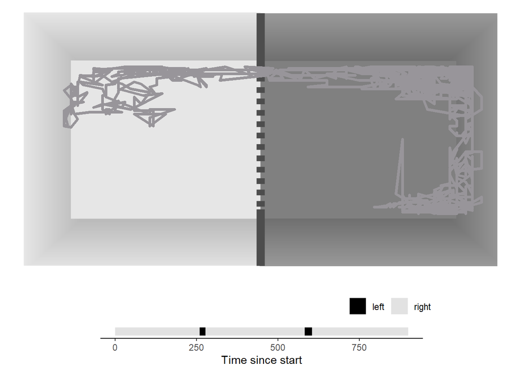

Animal:

animal_1

Distance:

25425.28

Time in left zone:

40.43

Time in right zone:

857.59

Time in central zone:

1.8

Crosses to the right:

2

Crosses to the left:

2

Number of freezes:

16

Total freeze time:

128.79

Freeze time ratio:

0.14

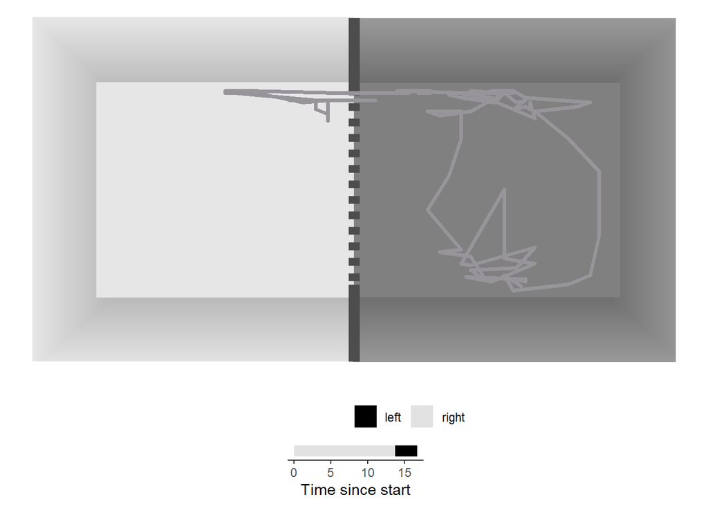

Animal:

animal_1

Distance:

2094.27

Time in left zone:

1.34

Time in right zone:

13.61

Time in central zone:

1.79

Crosses to the right:

0

Crosses to the left:

1

Number of freezes:

0

Total freeze time:

0

Freeze time ratio:

0

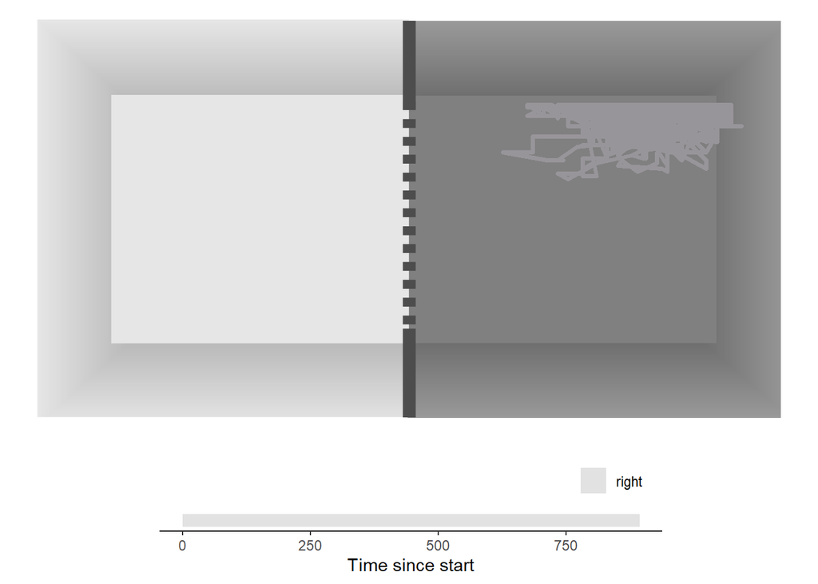

Animal:

animal_1

Distance:

25197.05

Time in left zone:

NA

Time in right zone:

894.19

Time in central zone:

NA

Crosses to the right:

0

Crosses to the left:

0

Number of freezes:

11

Total freeze time:

62.6

Freeze time ratio:

0.07

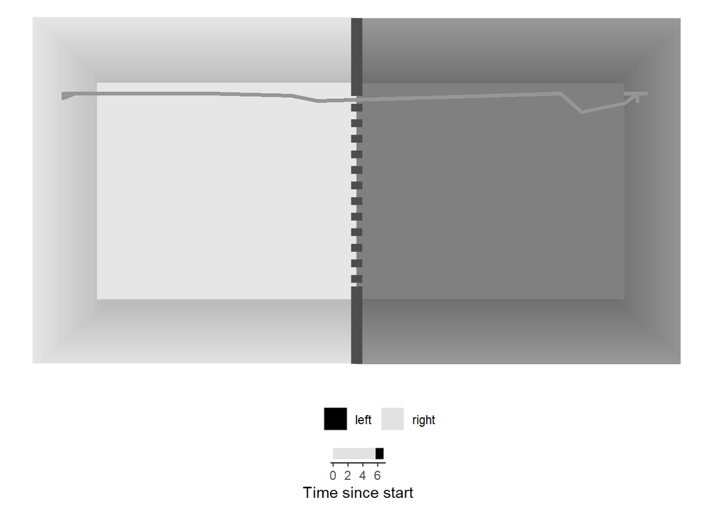

Animal:

animal_10

Distance:

498.8

Time in left zone:

1.01

Time in right zone:

5.76

Time in central zone:

NA

Crosses to the right:

0

Crosses to the left:

1

Number of freezes:

0

Total freeze time:

0

Freeze time ratio:

0

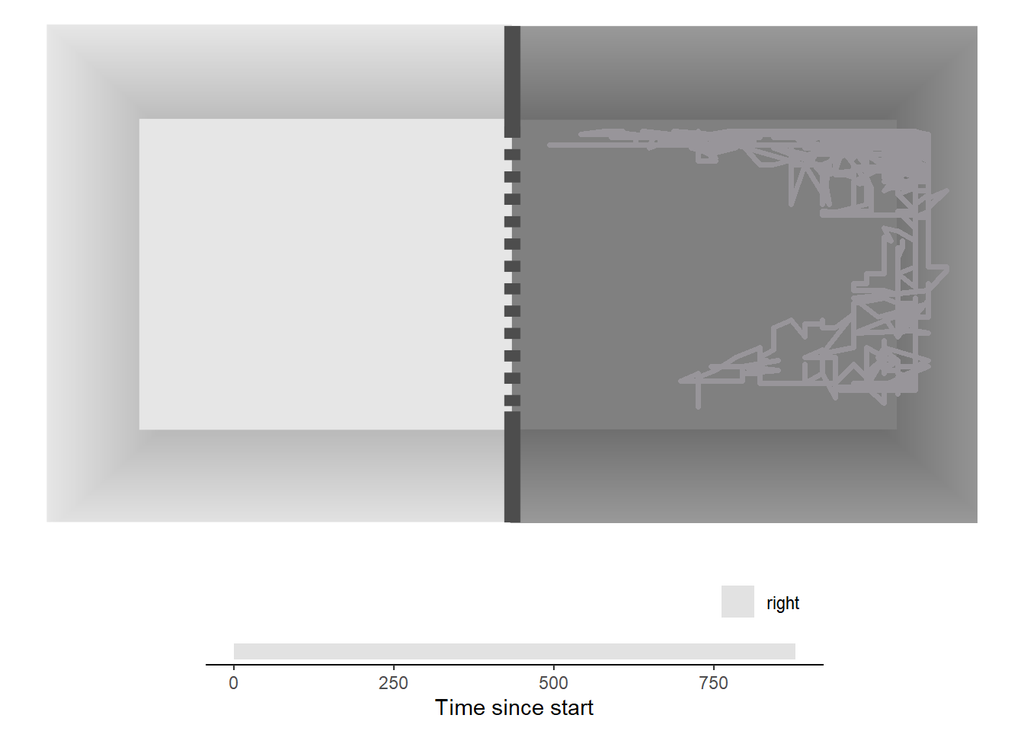

Animal:

animal_10

Distance:

21345.76

Time in left zone:

NA

Time in right zone:

877.04

Time in central zone:

0.45

Crosses to the right:

0

Crosses to the left:

0

Number of freezes:

8

Total freeze time:

62.82

Freeze time ratio:

0.07

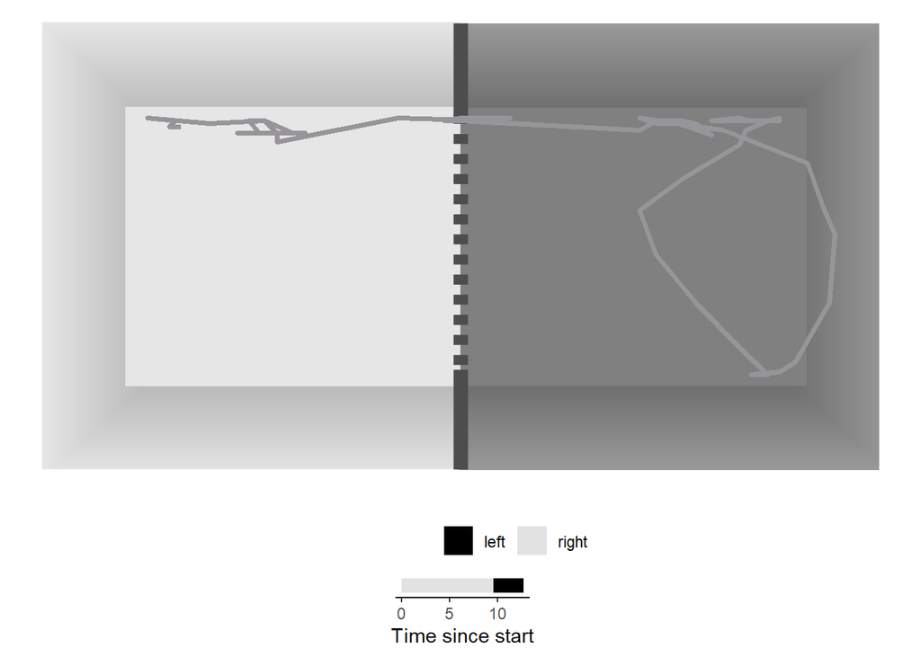

Animal:

animal_10

Distance:

1275.19

Time in left zone:

3.14

Time in right zone:

8.92

Time in central zone:

0.67

Crosses to the right:

0

Crosses to the left:

1

Number of freezes:

0

Total freeze time:

0

Freeze time ratio:

0

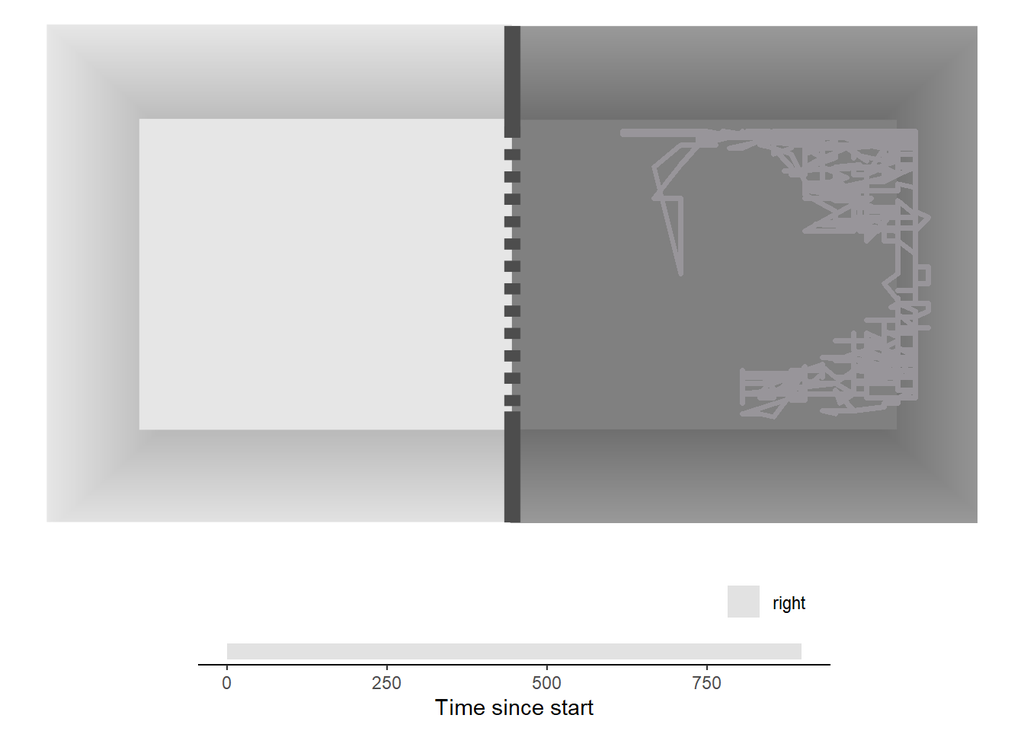

Animal:

animal_10

Distance:

13814.92

Time in left zone:

NA

Time in right zone:

897.61

Time in central zone:

NA

Crosses to the right:

0

Crosses to the left:

0

Number of freezes:

16

Total freeze time:

93.53

Freeze time ratio:

0.1

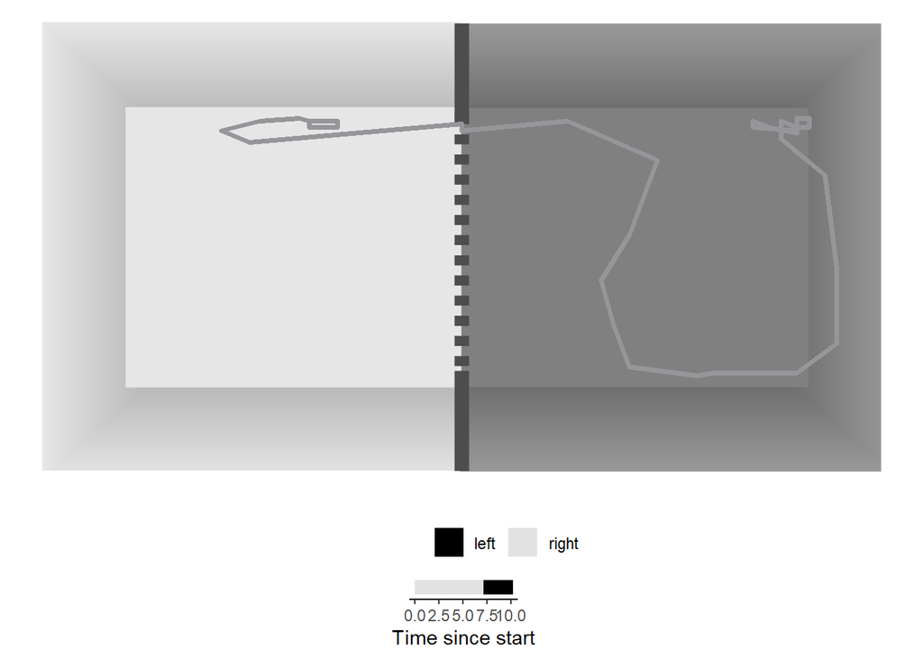

Animal:

animal_2

Distance:

982.3

Time in left zone:

3.03

Time in right zone:

6.98

Time in central zone:

0.22

Crosses to the right:

0

Crosses to the left:

1

Number of freezes:

0

Total freeze time:

0

Freeze time ratio:

0

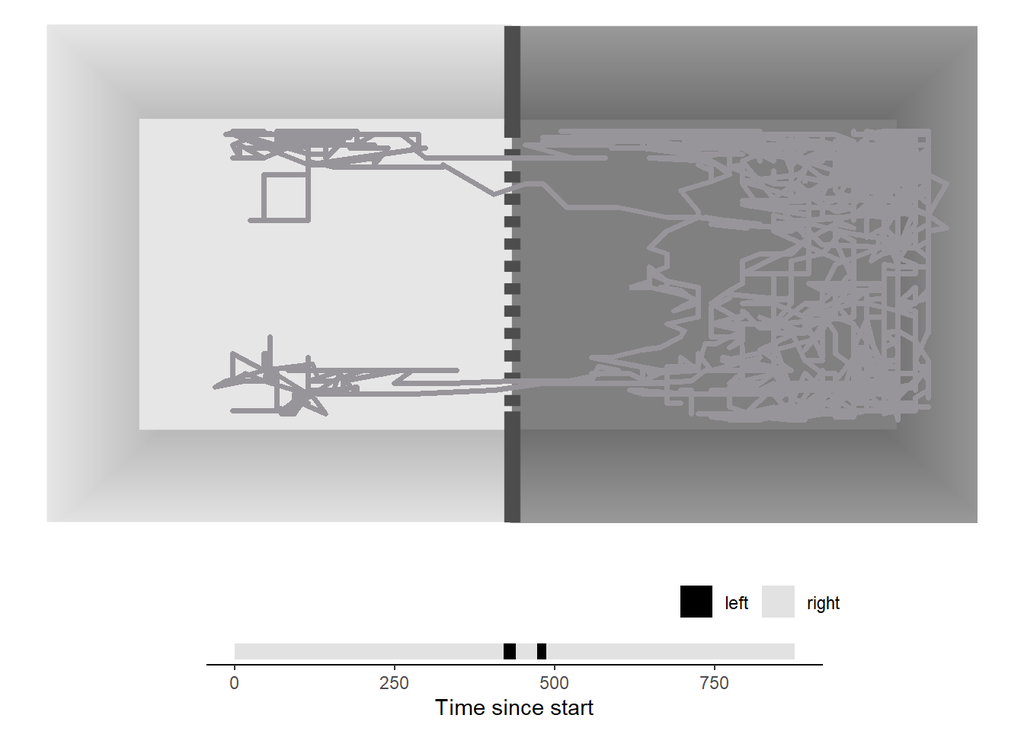

Animal:

animal_2

Distance:

29162.18

Time in left zone:

33.16

Time in right zone:

840.69

Time in central zone:

1.45

Crosses to the right:

2

Crosses to the left:

2

Number of freezes:

16

Total freeze time:

169.88

Freeze time ratio:

0.19

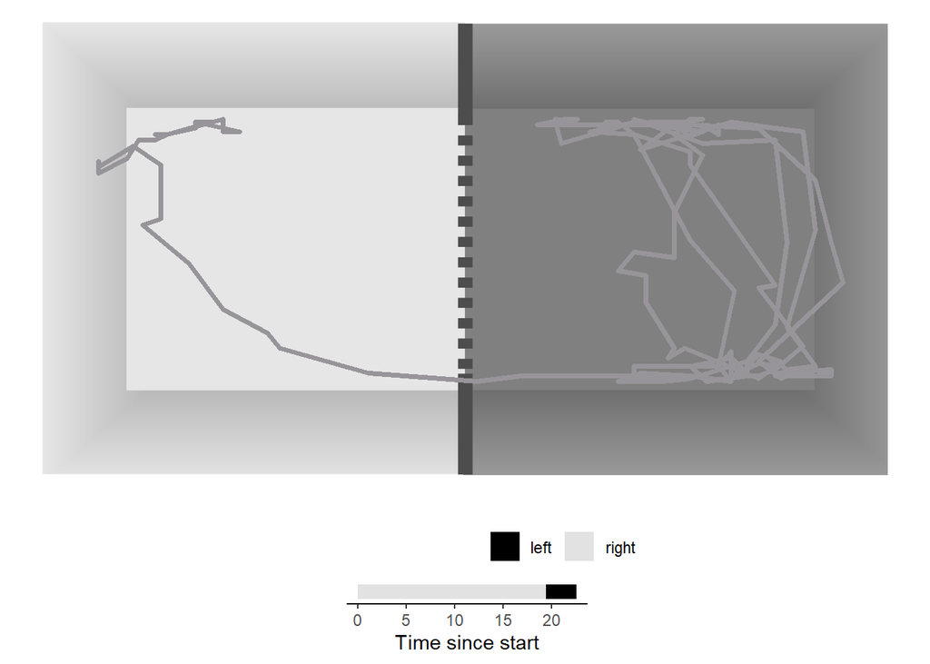

Animal:

animal_2

Distance:

3425.46

Time in left zone:

3.14

Time in right zone:

19.32

Time in central zone:

0.11

Crosses to the right:

0

Crosses to the left:

1

Number of freezes:

0

Total freeze time:

0

Freeze time ratio:

0

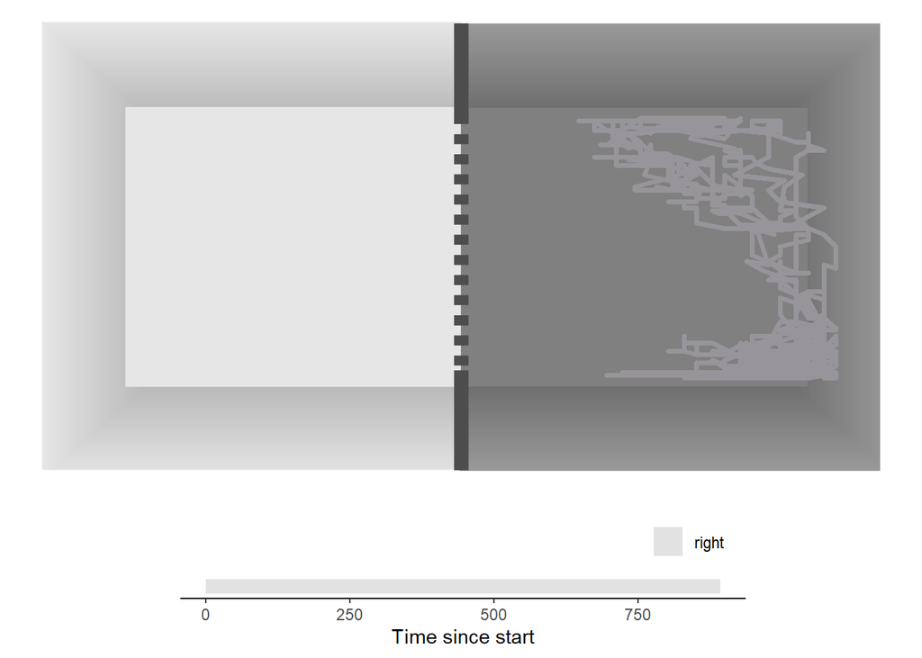

Animal:

animal_2

Distance:

16642.16

Time in left zone:

NA

Time in right zone:

892.21

Time in central zone:

NA

Crosses to the right:

0

Crosses to the left:

0

Number of freezes:

17

Total freeze time:

154.23

Freeze time ratio:

0.17

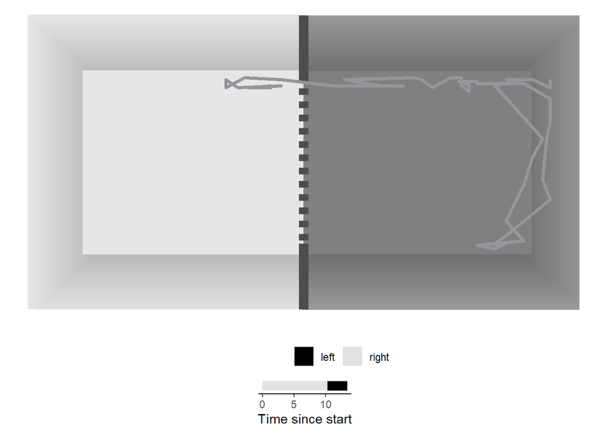

Animal:

animal_3

Distance:

1182.1

Time in left zone:

3.03

Time in right zone:

10.14

Time in central zone:

0.22

Crosses to the right:

0

Crosses to the left:

1

Number of freezes:

0

Total freeze time:

0

Freeze time ratio:

0

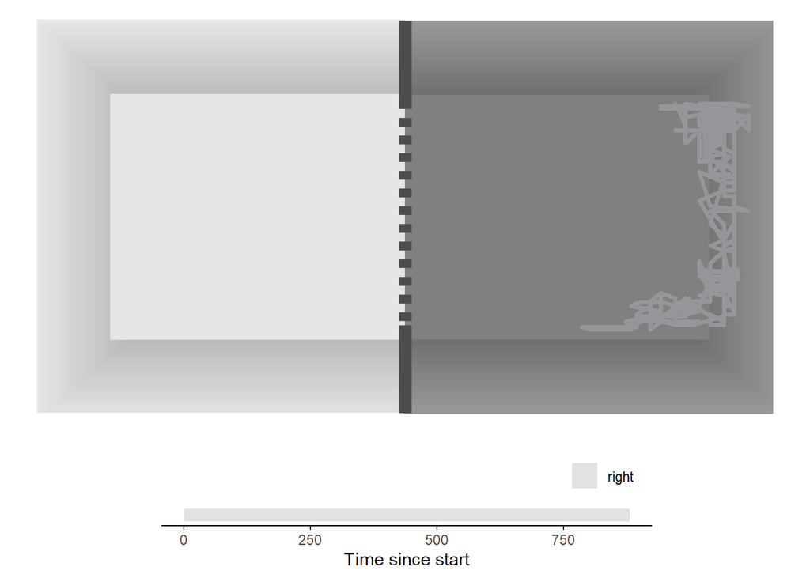

Animal:

animal_3

Distance:

11883.97

Time in left zone:

NA

Time in right zone:

881.6

Time in central zone:

NA

Crosses to the right:

0

Crosses to the left:

0

Number of freezes:

30

Total freeze time:

362.56

Freeze time ratio:

0.41

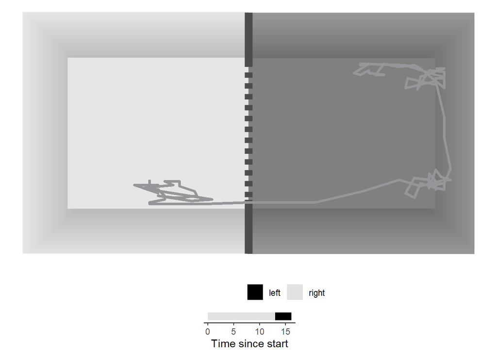

Animal:

animal_3

Distance:

1594.09

Time in left zone:

3.14

Time in right zone:

12.9

Time in central zone:

0.11

Crosses to the right:

0

Crosses to the left:

1

Number of freezes:

0

Total freeze time:

0

Freeze time ratio:

0

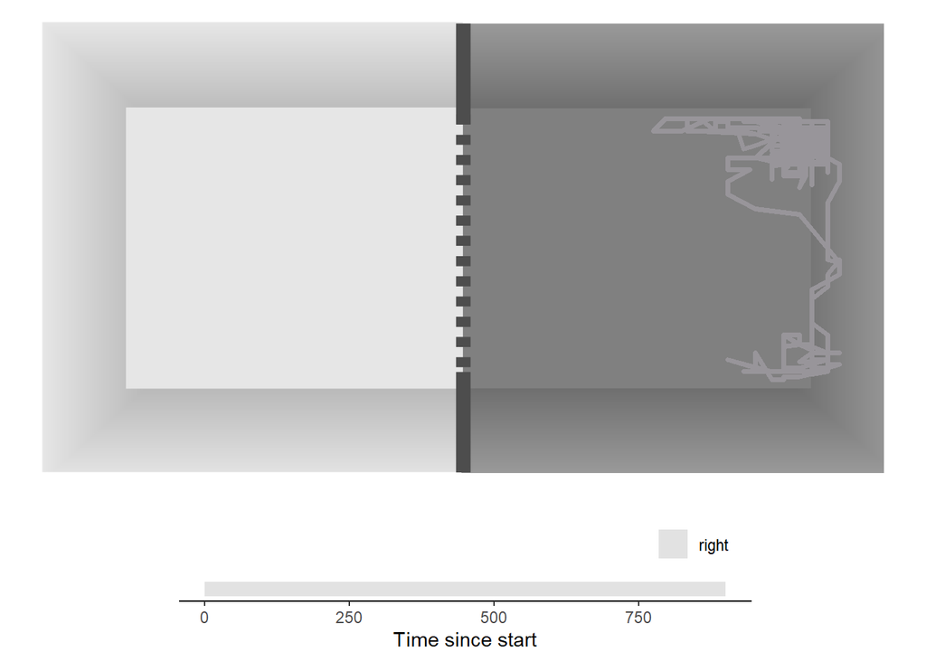

Animal:

animal_3

Distance:

10971.93

Time in left zone:

NA

Time in right zone:

899.49

Time in central zone:

NA

Crosses to the right:

0

Crosses to the left:

0

Number of freezes:

21

Total freeze time:

340.39

Freeze time ratio:

0.38

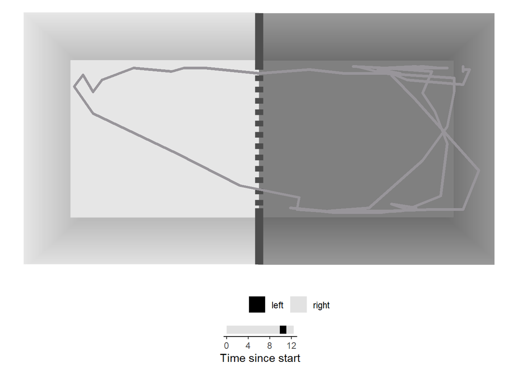

Animal:

animal_4

Distance:

2323.18

Time in left zone:

1.12

Time in right zone:

11.05

Time in central zone:

0.23

Crosses to the right:

1

Crosses to the left:

1

Number of freezes:

0

Total freeze time:

0

Freeze time ratio:

0

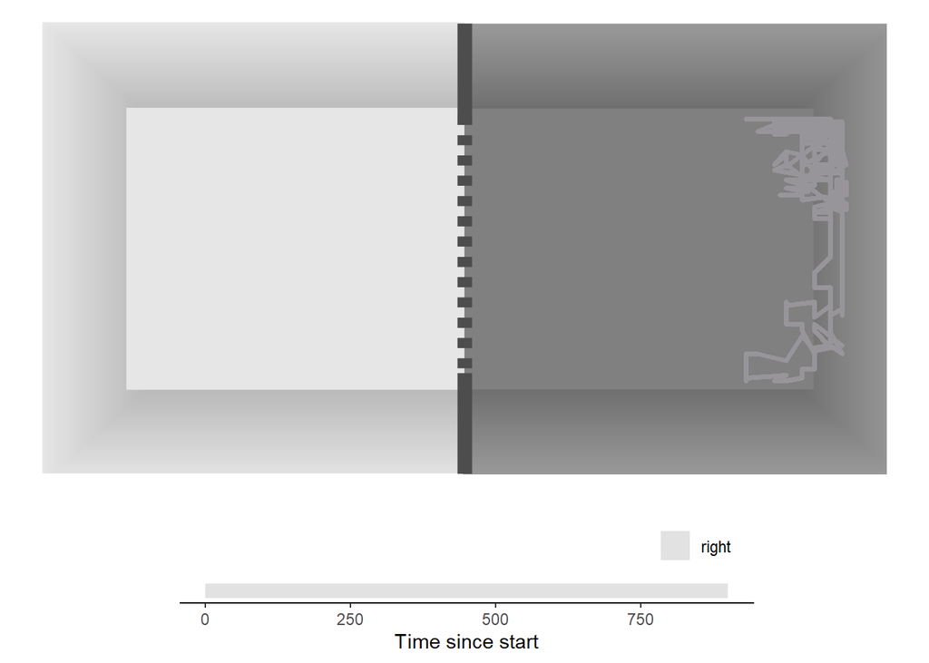

Animal:

animal_4

Distance:

10586.39

Time in left zone:

NA

Time in right zone:

899.43

Time in central zone:

NA

Crosses to the right:

0

Crosses to the left:

0

Number of freezes:

30

Total freeze time:

355.58

Freeze time ratio:

0.4

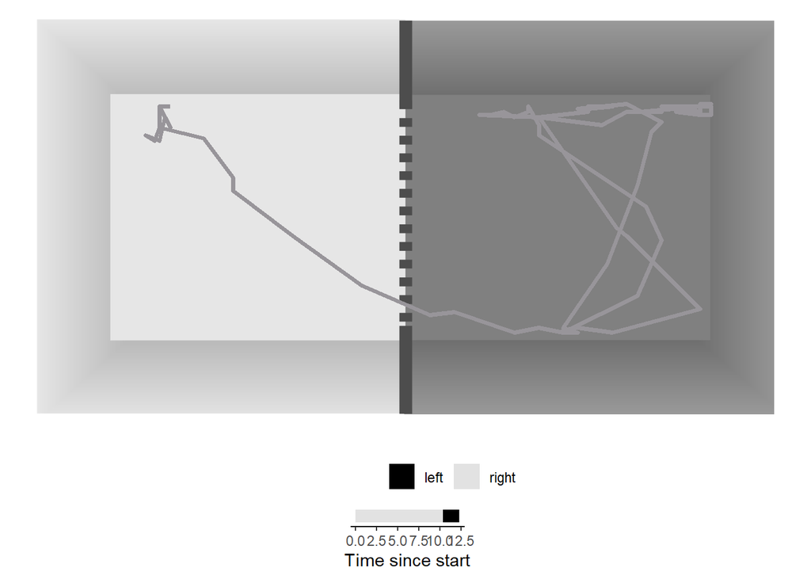

Animal:

animal_4

Distance:

1819.89

Time in left zone:

1.9

Time in right zone:

10.26

Time in central zone:

0.11

Crosses to the right:

0

Crosses to the left:

1

Number of freezes:

0

Total freeze time:

0

Freeze time ratio:

0

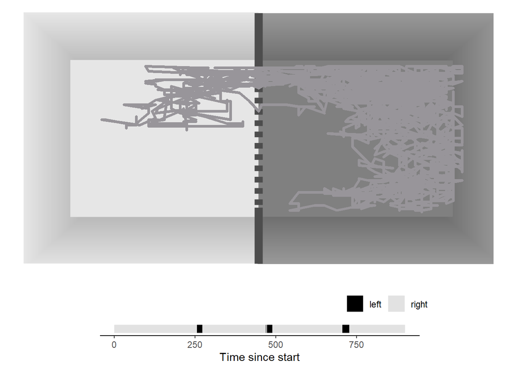

Animal:

animal_4

Distance:

38486.45

Time in left zone:

44.84

Time in right zone:

840.93

Time in central zone:

13.83

Crosses to the right:

4

Crosses to the left:

4

Number of freezes:

1

Total freeze time:

12.77

Freeze time ratio:

0.01

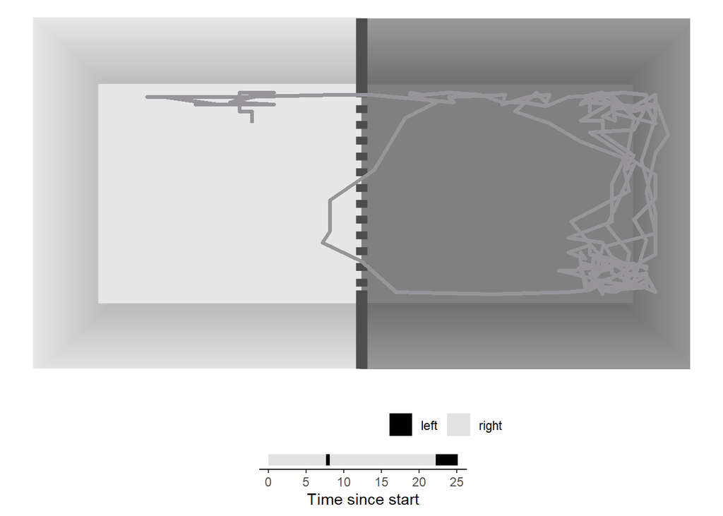

Animal:

animal_5

Distance:

3934.58

Time in left zone:

3.24

Time in right zone:

21.41

Time in central zone:

0.46

Crosses to the right:

1

Crosses to the left:

2

Number of freezes:

0

Total freeze time:

0

Freeze time ratio:

0

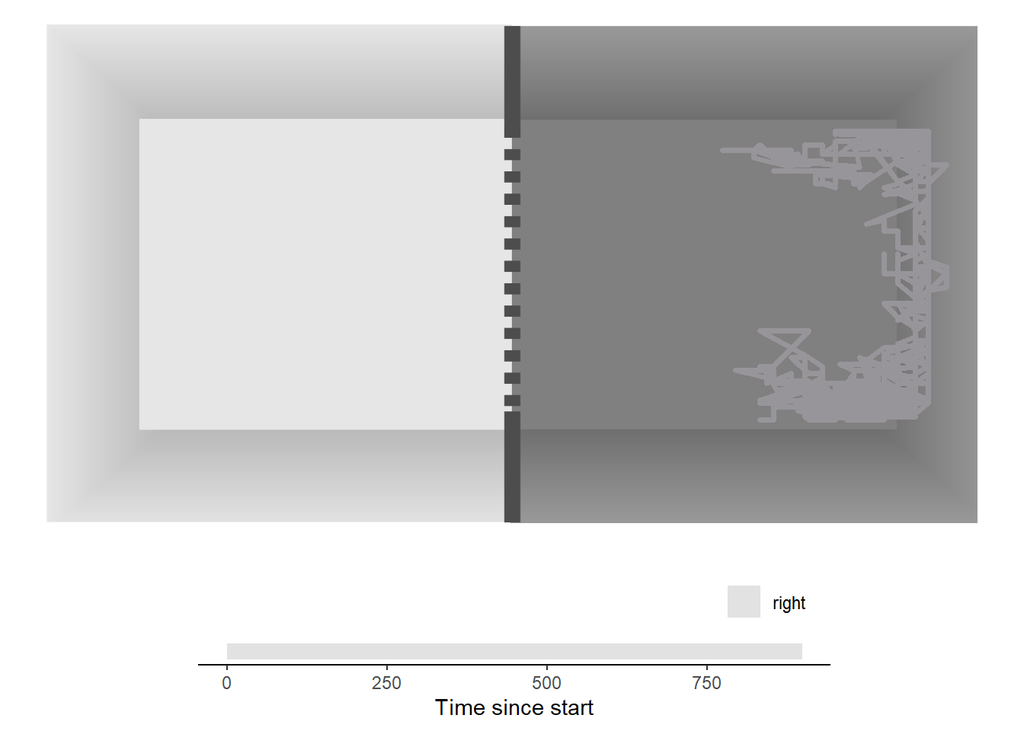

Animal:

animal_5

Distance:

13679.06

Time in left zone:

NA

Time in right zone:

898.7